# IST 707 HW1

## Dashboard Link: https://yvelapal.shinyapps.io/HW01/

### Loading the data

```r
df<-read.csv('employee data.csv')
```

## DATA UNDERSTANDING

#### *Exploring the Structure of the Data*

```r
str(df)
```

```
## 'data.frame':    1176 obs. of  35 variables:
##  $ Age                     : int  30 52 42 55 35 51 42 23 38 27 ...
##  $ Attrition               : Factor w/ 2 levels "No","Yes": 1 1 1 1 1 1 1 1 1 2 ...
##  $ BusinessTravel          : Factor w/ 3 levels "Non-Travel","Travel_Frequently",..: 3 3 3 1 3 3 3 3 3 3 ...
##  $ DailyRate               : int  1358 1325 462 177 1029 1318 932 507 1153 1420 ...
##  $ Department              : Factor w/ 3 levels "Human Resources",..: 3 2 3 2 2 3 2 2 2 3 ...
##  $ DistanceFromHome        : int  16 11 14 8 16 26 1 20 6 2 ...
##  $ Education               : int  1 4 2 1 3 4 2 1 2 1 ...
##  $ EducationField          : Factor w/ 6 levels "Human Resources",..: 2 2 4 4 2 3 2 2 5 3 ...
##  $ EmployeeCount           : int  1 1 1 1 1 1 1 1 1 1 ...
##  $ EmployeeNumber          : int  1479 813 936 1278 1529 851 827 1533 1782 667 ...
##  $ EnvironmentSatisfaction : int  4 4 3 4 4 1 4 1 4 3 ...
##  $ Gender                  : Factor w/ 3 levels "","Female","Male": 3 2 2 3 2 2 2 3 2 3 ...
##  $ HourlyRate              : int  96 82 68 37 91 66 43 97 40 85 ...
##  $ JobInvolvement          : int  3 3 2 2 2 3 2 3 2 3 ...
```

[output cut: 21 more lines]

###### *Structure of the Dataset : 1176 observations with 35 variables.*

#### *Summary of the Data*

```r
summary(df)
```

```
##       Age        Attrition           BusinessTravel   DailyRate
##  Min.   :18.00   No :991   Non-Travel       :110    Min.   : 102.0
##  1st Qu.:30.00   Yes:185   Travel_Frequently:227    1st Qu.: 461.8
##  Median :36.00             Travel_Rarely    :839    Median : 796.0
##  Mean   :36.96                                      Mean   : 800.4
##  3rd Qu.:43.00                                      3rd Qu.:1162.0
##  Max.   :60.00                                      Max.   :1499.0
##
##                   Department  DistanceFromHome    Education
##  Human Resources       : 54   Min.   :  1.000   Min.   :1.000
##  Research & Development:764   1st Qu.:  2.000   1st Qu.:2.000
##  Sales                 :358   Median :  7.000   Median :3.000
##                               Mean   :  9.496   Mean   :2.895
##                               3rd Qu.: 14.000   3rd Qu.:4.000
##                               Max.   :224.000   Max.   :5.000
##                               NA's   :2
##           EducationField EmployeeCount EmployeeNumber
##  Human Resources : 25    Min.   :1     Min.   :   1.0
##  Life Sciences   :477    1st Qu.:1     1st Qu.: 499.8
##  Marketing       :127    Median :1     Median :1032.5
##  Medical         :381    Mean   :1     Mean   :1036.4
##  Other           : 69    3rd Qu.:1     3rd Qu.:1574.5
##  Technical Degree: 97    Max.   :1     Max.   :2068.0
##
##  EnvironmentSatisfaction    Gender      HourlyRate     JobInvolvement
##  Min.   :1.000                 :  1   Min.   : 30.00   Min.   :1.000
##  1st Qu.:2.000           Female:482   1st Qu.: 48.00   1st Qu.:2.000
##  Median :3.000           Male  :693   Median : 66.00   Median :3.000
##  Mean   :2.705                        Mean   : 65.82   Mean   :2.741
##  3rd Qu.:4.000                        3rd Qu.: 83.00   3rd Qu.:3.000
##  Max.   :4.000                        Max.   :100.00   Max.   :4.000
##
##     JobLevel                          JobRole    JobSatisfaction
##  Min.   :1.000   Sales Executive          :263   Min.   :1.00
##  1st Qu.:1.000   Research Scientist       :220   1st Qu.:2.00
##  Median :2.000   Laboratory Technician    :209   Median :3.00
##  Mean   :2.069   Manufacturing Director   :122   Mean   :2.71
##  3rd Qu.:3.000   Healthcare Representative:108   3rd Qu.:4.00
##  Max.   :5.000   Manager                  : 79   Max.   :4.00
##  NA's   :1       (Other)                  :175
```

[output cut: 25 more lines]

```
##  Min.   :0.00          Min.   :1.000   Min.   : 0.000   Min.   : 0.000
##  1st Qu.:2.00          1st Qu.:2.000   1st Qu.: 3.000   1st Qu.: 2.000
##  Median :3.00          Median :3.000   Median : 5.000   Median : 3.000
##  Mean   :2.81          Mean   :2.747   Mean   : 6.918   Mean   : 4.151
##  3rd Qu.:3.00          3rd Qu.:3.000   3rd Qu.: 9.000   3rd Qu.: 7.000
##  Max.   :6.00          Max.   :4.000   Max.   :40.000   Max.   :18.000
##
##  YearsSinceLastPromotion YearsWithCurrManager
##  Min.   : 0.000          Min.   :  0.000
##  1st Qu.: 0.000          1st Qu.:  2.000
##  Median : 1.000          Median :  3.000
##  Mean   : 2.125          Mean   :  4.242
##  3rd Qu.: 2.000          3rd Qu.:  7.000
##  Max.   :15.000          Max.   :219.000
##  NA's   :1
```

*From the summary we can observe the descriptive statistics of the numerical variables.* *Incase of categroical variables we can identify the levels that are present in each variable.* *Also we observe there is a blank observation in Gender and OverTime columns.*

#### *Dealing with Blank values in Gender and OverTime*

*Replacing blank values with NA’s*

```r
df$Gender[df$Gender==""]<- NA
df$OverTime[df$OverTime==""]<- NA
```

#### *Converting Gender and OverTime to character type*

*Gender and OverTime variables will be converted to character type and then reconverted to factors to adjust the levels*

```r
df$Gender<-as.character(df$Gender)
df$OverTime<-as.character(df$OverTime)
```

#### *Converting the necessary variables to factors*

```r
df$Gender<-as.factor(df$Gender)
df$OverTime<-as.factor(df$OverTime)
df$Education<-as.factor(df$Education)
df$EnvironmentSatisfaction<-as.factor(df$EnvironmentSatisfaction)
df$JobInvolvement<-as.factor(df$JobInvolvement)
df$JobLevel<-as.factor(df$JobLevel)
df$JobSatisfaction<-as.factor(df$JobSatisfaction)
df$PerformanceRating<-as.factor(df$PerformanceRating)
df$RelationshipSatisfaction<-as.factor(df$RelationshipSatisfaction)
df$StockOptionLevel<-as.factor(df$StockOptionLevel)
df$WorkLifeBalance<-as.factor(df$WorkLifeBalance)
df$TrainingTimesLastYear<-as.factor(df$TrainingTimesLastYear)
```

#### *Deleting unnecessary columns*

```r
df<-df[,-c(9,10,22,27)]
```

#### *Finding the missing values in the data*

```r
sum(!complete.cases(df))
```

```
## [1] 11
```

```r
sapply(df,function(x)sum(is.na(x)))
```

```
##                      Age                Attrition           BusinessTravel
##                        0                        0                        0
##                DailyRate               Department         DistanceFromHome
##                        0                        0                        2
##                Education           EducationField  EnvironmentSatisfaction
##                        0                        0                        0
##                   Gender               HourlyRate           JobInvolvement
##                        1                        0                        0
##                 JobLevel                  JobRole          JobSatisfaction
##                        1                        0                        0
##            MaritalStatus            MonthlyIncome              MonthlyRate
##                        0                        0                        0
##       NumCompaniesWorked                 OverTime        PercentSalaryHike
##                        0                        1                        1
##        PerformanceRating RelationshipSatisfaction         StockOptionLevel
##                        1                        1                        0
##        TotalWorkingYears    TrainingTimesLastYear          WorkLifeBalance
##                        2                        0                        0
##           YearsAtCompany       YearsInCurrentRole  YearsSinceLastPromotion
##                        0                        0                        1
##     YearsWithCurrManager
##                        0
```

#### *Replacing the missing values of numerical variables by Mean Imputation*

```r
df$DistanceFromHome[is.na(df$DistanceFromHome)]<-mean(df$DistanceFromHome,na.rm = TRUE)
df$PercentSalaryHike[is.na(df$PercentSalaryHike)]<-mean(df$PercentSalaryHike,na.rm = TRUE)
df$TotalWorkingYears[is.na(df$TotalWorkingYears)]<-mean(df$TotalWorkingYears,na.rm = TRUE)
df$YearsSinceLastPromotion[is.na(df$YearsSinceLastPromotion)]<-mean(df$YearsSinceLastPromotion,na.rm = TRUE)
```

#### *Replacing the missing values of categorical variables by kNN imputation*

```r
df <- knnImputation(df)
```

#### *Re-checking for missing values and duplicated data*

```r
sum(!complete.cases(df))
```

```
## [1] 0
```

```r
sum(duplicated(df))
```

```
## [1] 0
```

#### *Looking at the Attrition Variable*

```r
prop.table(table(df$Attrition))*100
```

```
##
##       No      Yes
## 84.26871 15.73129
```

*From the Attrition percentage table, we can observe that 84.268% of the employees stay in the company and only 15.73% of the employees leave the company.* *This is an imbalanced dataset.*

## VISUALIZATION

#### *Correlation Plot*

*Drawing a corrleation plot for numerical attributes*

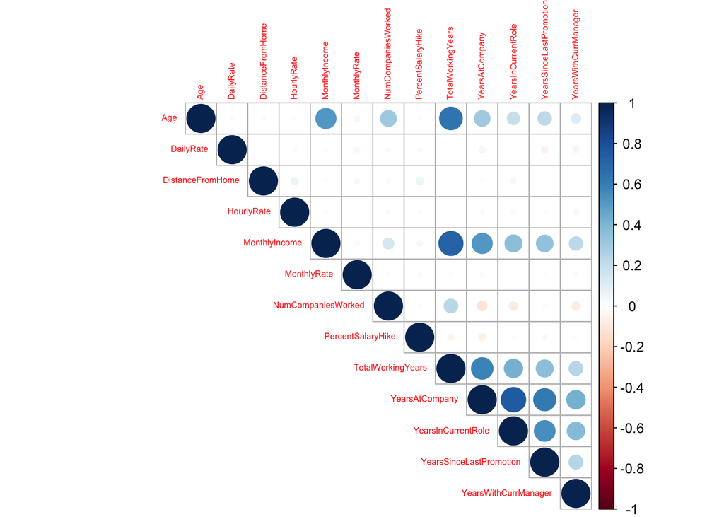

```r
c<-data.frame(df[,c(1,4,6,11,17,18,19,21,25,28,29,30,31)])
corrplot(cor(c),method = 'circle', type='upper',tl.cex = 0.5)
```

*From the plot, we can observe the relation between various numerical attributes. The blue circles indicate positive correlation and red circles indicate negative correlation.*

### PLOTTING THE ATTRIBUTES AGAINST ATTRITION

#### *Age*

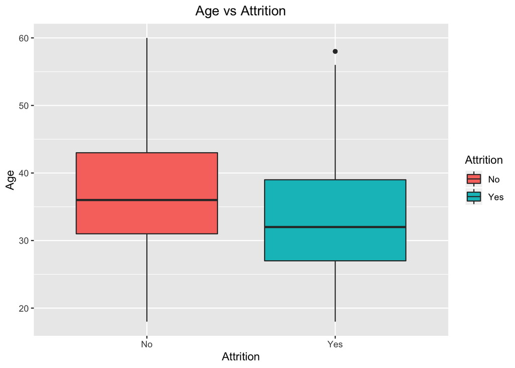

```r
ggplot(df, aes(x=Attrition,y=Age, fill=Attrition))+ geom_boxplot()+ggtitle('Age vs Attrition')+theme(plot.title = element_text(hjust = 0.5))
```

*From the plot, it is understood that Attrition is high in younger employees.*

#### *Business Travel*

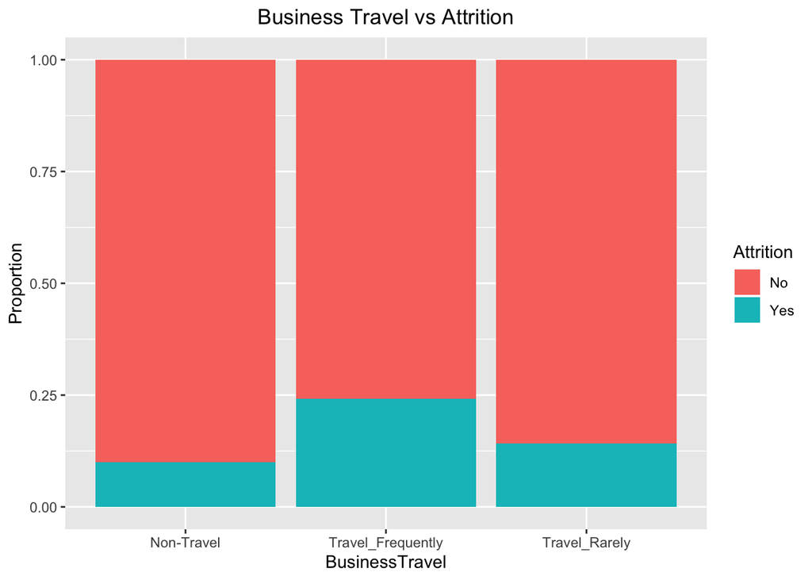

```r
ggplot(df, aes(x=BusinessTravel,fill=Attrition)) + geom_bar(position = position_fill()) +
  labs(y="Proportion")+ggtitle('Business Travel vs Attrition')+theme(plot.title = element_text(hjust = 0.5))
```

*From the plot, we can interpret that attrition is high in employees who travel frequently.*

#### *Department*

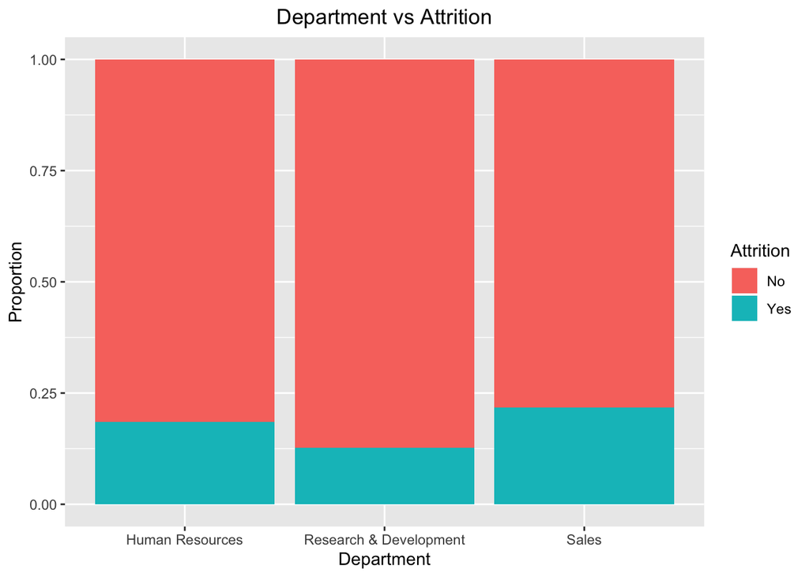

```r
ggplot(df, aes(x=Department,fill=Attrition)) + geom_bar(position = position_fill()) +
  labs(y="Proportion")+ggtitle('Department vs Attrition')+theme(plot.title = element_text(hjust = 0.5))
```

#### *Distance From Home*

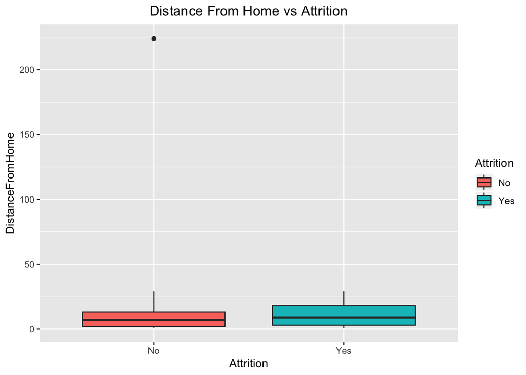

```r
ggplot(df,aes(x=Attrition, y=DistanceFromHome, fill=Attrition))+geom_boxplot()+ggtitle('Distance From Home vs Attrition')+theme(plot.title = element_text(hjust = 0.5))
```

*Employees who lives far from work has a higher chance of leaving the company*

#### *Education*

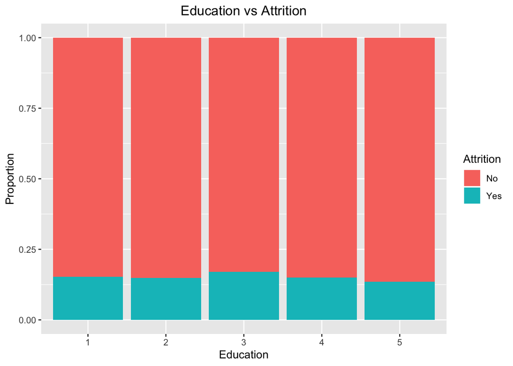

```r
ggplot(df, aes(x=Education,fill=Attrition)) + geom_bar(position = position_fill()) +
  labs(y="Proportion")+ggtitle('Education vs Attrition')+theme(plot.title = element_text(hjust = 0.5))
```

*From the plot, it is clear that Education has no effect on Attrition*

#### *Education Field*

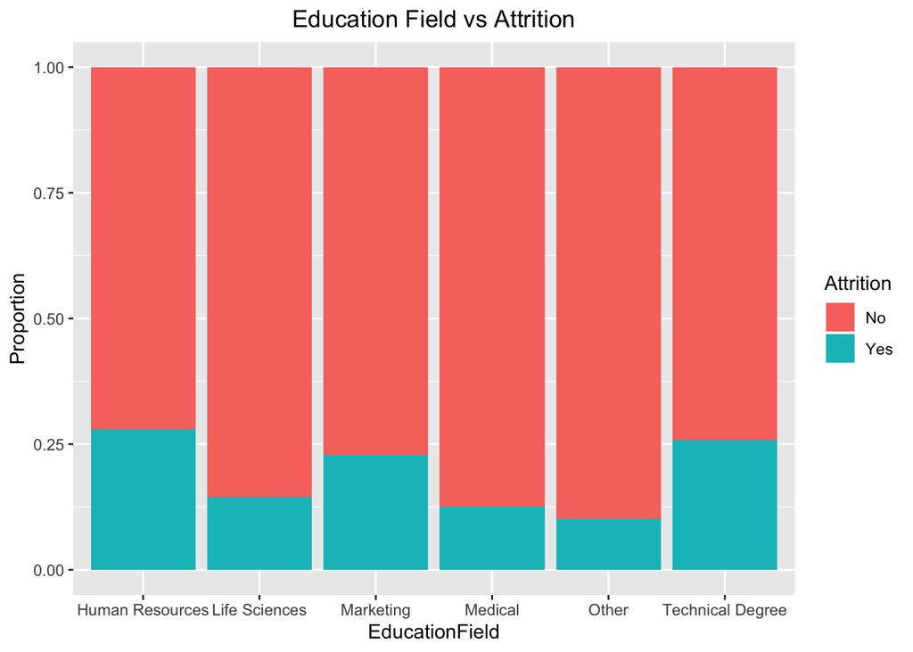

```r
ggplot(df, aes(x=EducationField,fill=Attrition)) + geom_bar(position = position_fill()) +
  labs(y="Proportion")+ggtitle('Education Field vs Attrition')+theme(plot.title = element_text(hjust = 0.5))
```

*Employees in the field of HR, Marketing and some technical degree have higher Attrition rate*

#### *Environment Satisfaction*

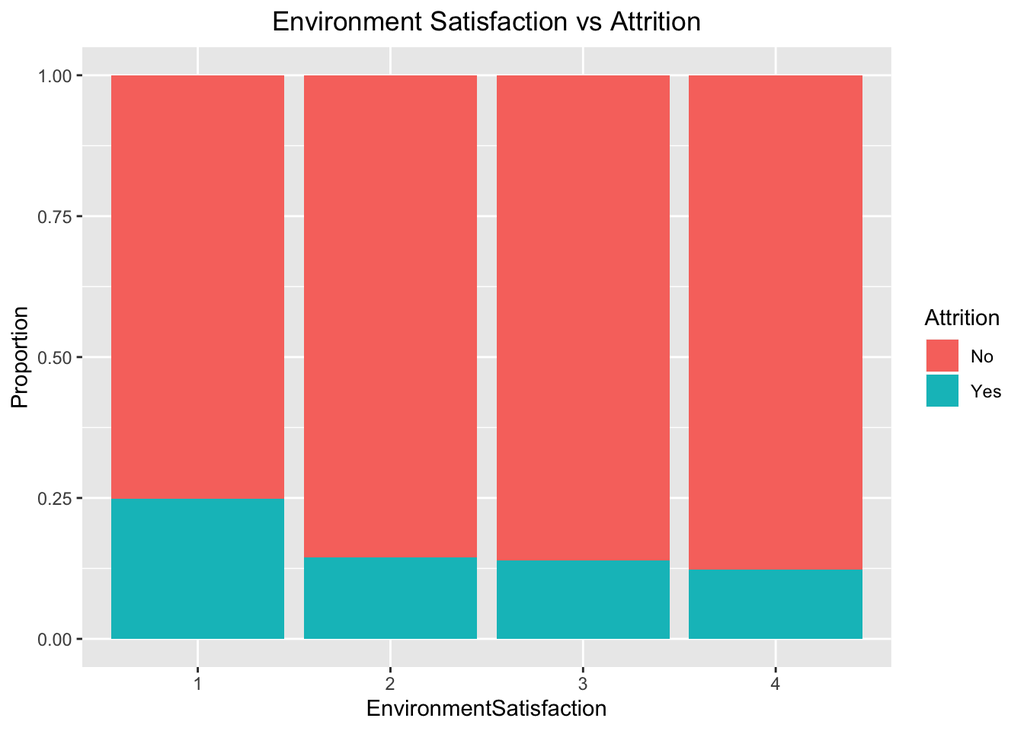

```r
ggplot(df, aes(x=EnvironmentSatisfaction,fill=Attrition)) + geom_bar(position = position_fill()) + labs(y="Proportion")+ggtitle('Environment Satisfaction vs Attrition')+theme(plot.title = element_text(hjust = 0.5))
```

*Attrition is high in Employees with low Environment satisfaction*

#### *Gender*

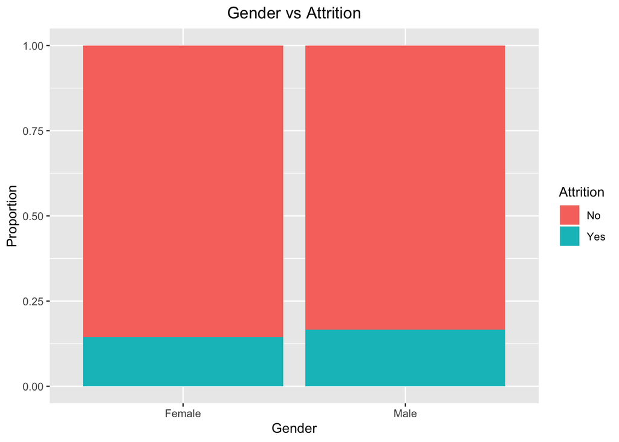

```r
ggplot(df, aes(x=Gender,fill=Attrition)) + geom_bar(position = position_fill()) +
  labs(y="Proportion")+ggtitle('Gender vs Attrition')+theme(plot.title = element_text(hjust = 0.5))
```

*Male Employees has higher attrition compared to Female Employees*

#### *Job Involvement*

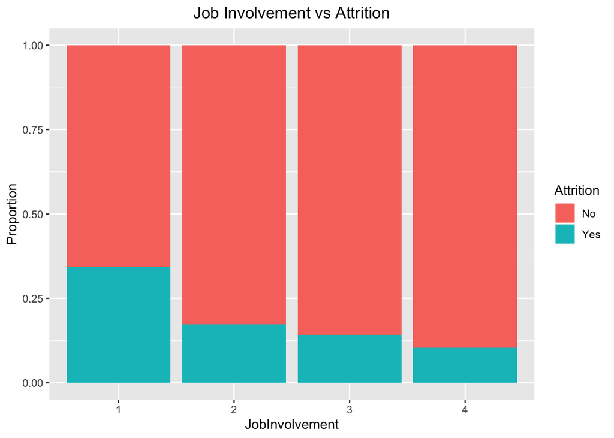

```r
ggplot(df, aes(x=JobInvolvement,fill=Attrition)) + geom_bar(position = position_fill()) +
  labs(y="Proportion")+ggtitle('Job Involvement vs Attrition')+theme(plot.title = element_text(hjust = 0.5))
```

*Attrition is high in Employees who are less involved in their jobs*

#### *Job Satisfaction*

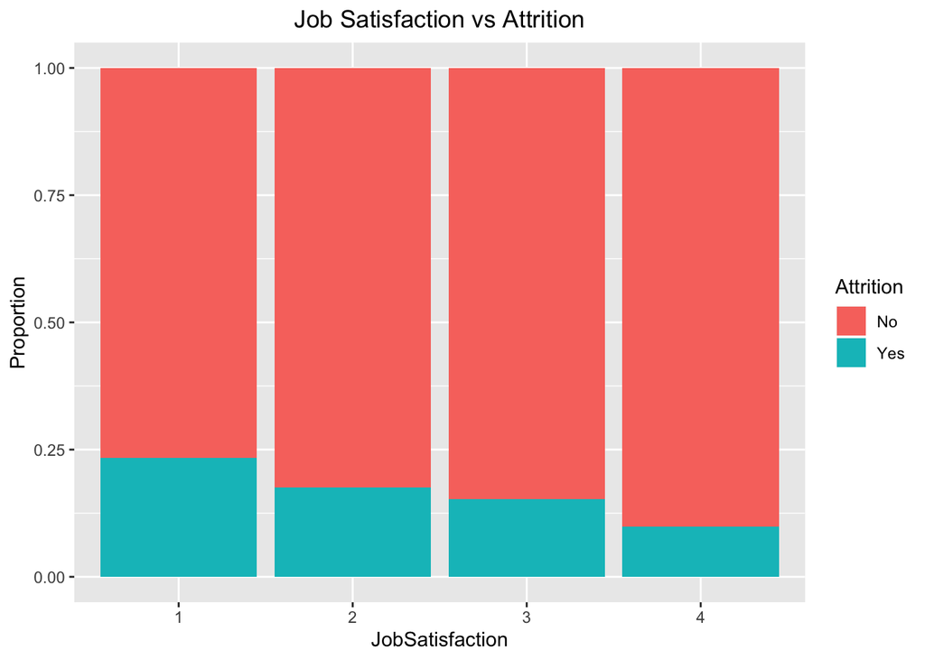

```r
ggplot(df, aes(x=JobSatisfaction,fill=Attrition)) + geom_bar(position = position_fill()) +
  labs(y="Proportion")+ggtitle('Job Satisfaction vs Attrition')+theme(plot.title = element_text(hjust = 0.5))
```

*Attrition is high in Employees with low Job Satisfaction*

#### *Marital Status*

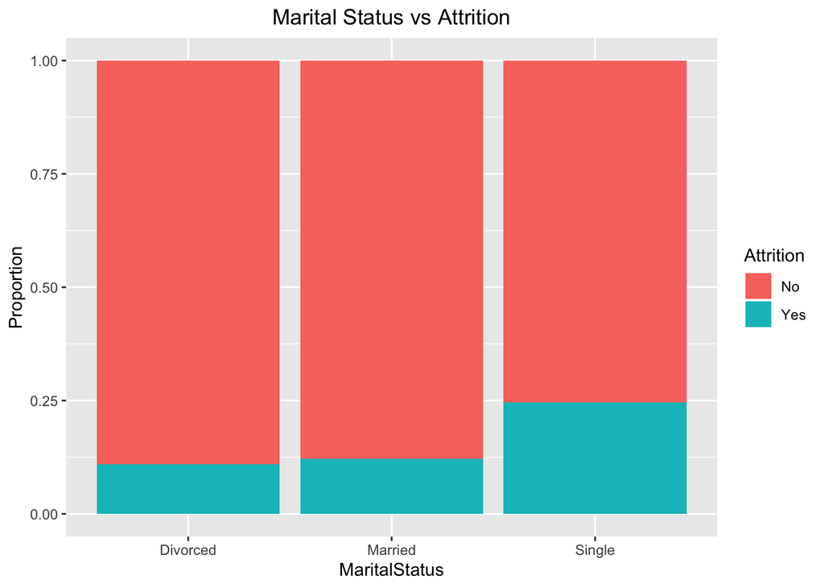

```r
ggplot(df, aes(x=MaritalStatus,fill=Attrition)) + geom_bar(position = position_fill()) +
  labs(y="Proportion")+ggtitle('Marital Status vs Attrition')+theme(plot.title = element_text(hjust = 0.5))
```

*Attrition is low among Divorced/Married employees and high in Single employees*

#### *Monthly Income*

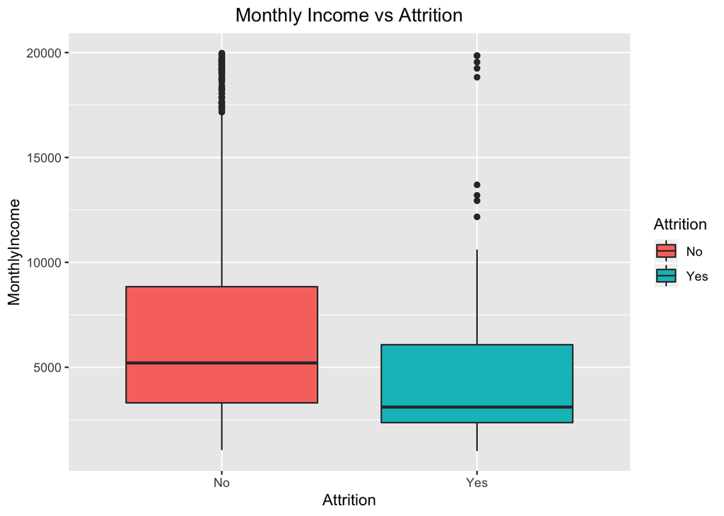

```r
ggplot(df,aes(x=Attrition,y=MonthlyIncome, fill=Attrition))+geom_boxplot()+ggtitle('Monthly Income vs Attrition')+theme(plot.title = element_text(hjust = 0.5))
```

*Attrition is high in employees with low montly income*

#### *Number of Companies Worked*

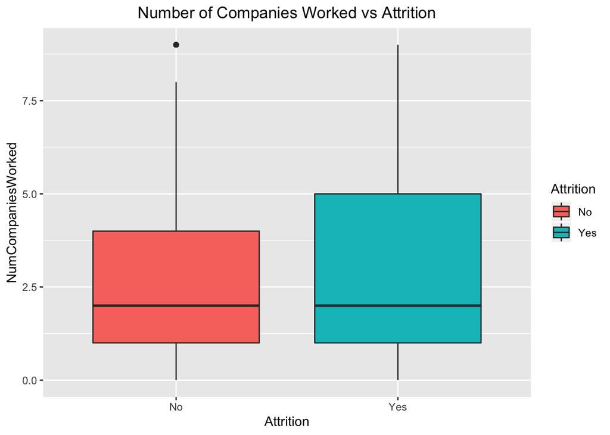

```r
ggplot(df,aes(x=Attrition,y=NumCompaniesWorked,fill=Attrition))+geom_boxplot()+ggtitle('Number of Companies Worked vs Attrition')+theme(plot.title = element_text(hjust = 0.5))
```

*Employees who hopped more jobs tend to leave the company*

#### *OverTime*

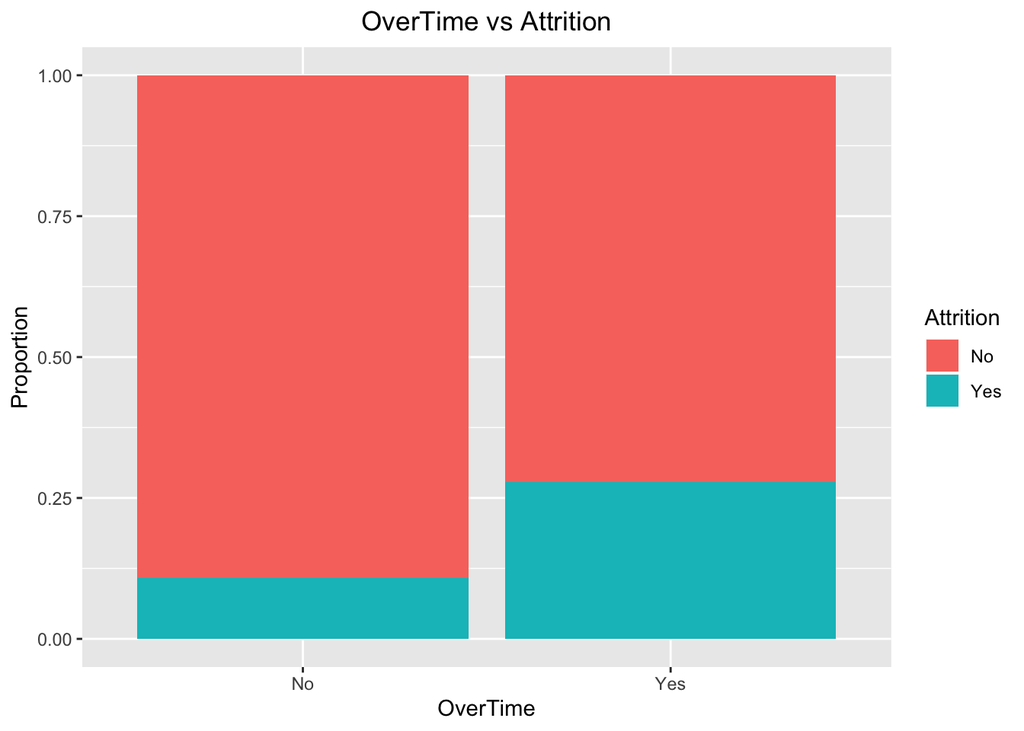

```r
ggplot(df, aes(x=OverTime,fill=Attrition)) + geom_bar(position = position_fill()) +
  labs(y="Proportion")+ggtitle('OverTime vs Attrition')+theme(plot.title =   element_text(hjust = 0.5))
```

*Attrition is high in employees who are made to work overtime*

#### *Percent Salary Hike*

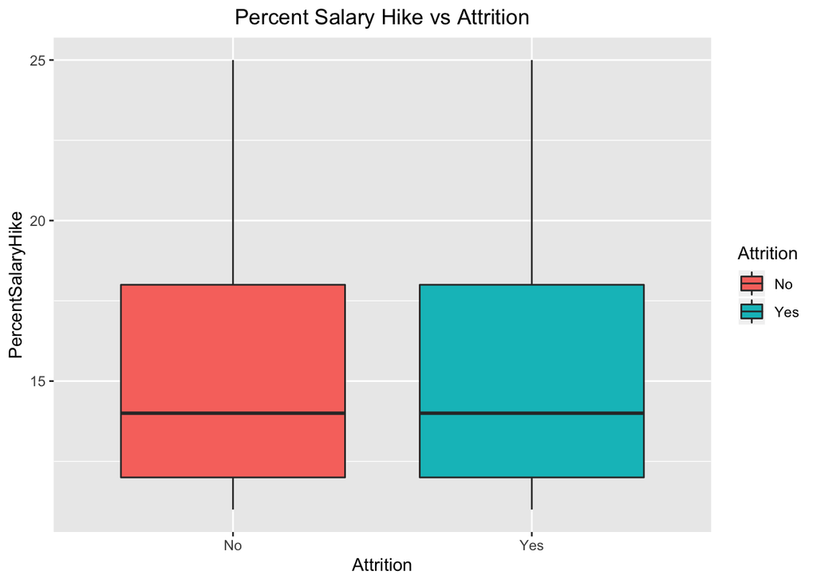

```r
ggplot(df,aes(x=Attrition,y=PercentSalaryHike,fill=Attrition))+geom_boxplot()+ggtitle('Percent Salary Hike vs Attrition')+theme(plot.title = element_text(hjust = 0.5))
```

*From the plot, it seems Percent Salary Hike has no or liitle effect on Atrition*

#### *StockOption Level*

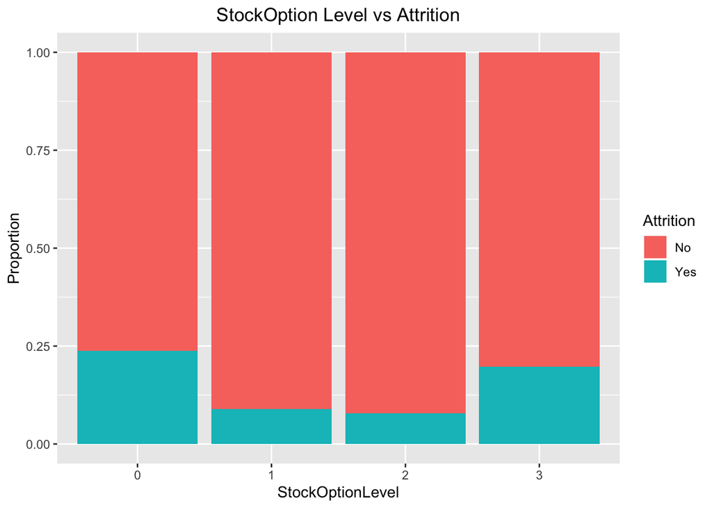

```r
ggplot(df, aes(x=StockOptionLevel,fill=Attrition)) + geom_bar(position = position_fill()) + labs(y="Proportion")+ggtitle('StockOption Level vs Attrition')+theme(plot.title = element_text(hjust = 0.5))
```

*Whenever the Stock option level is at extreme values the Attrition is high*

#### *Total Working Years*

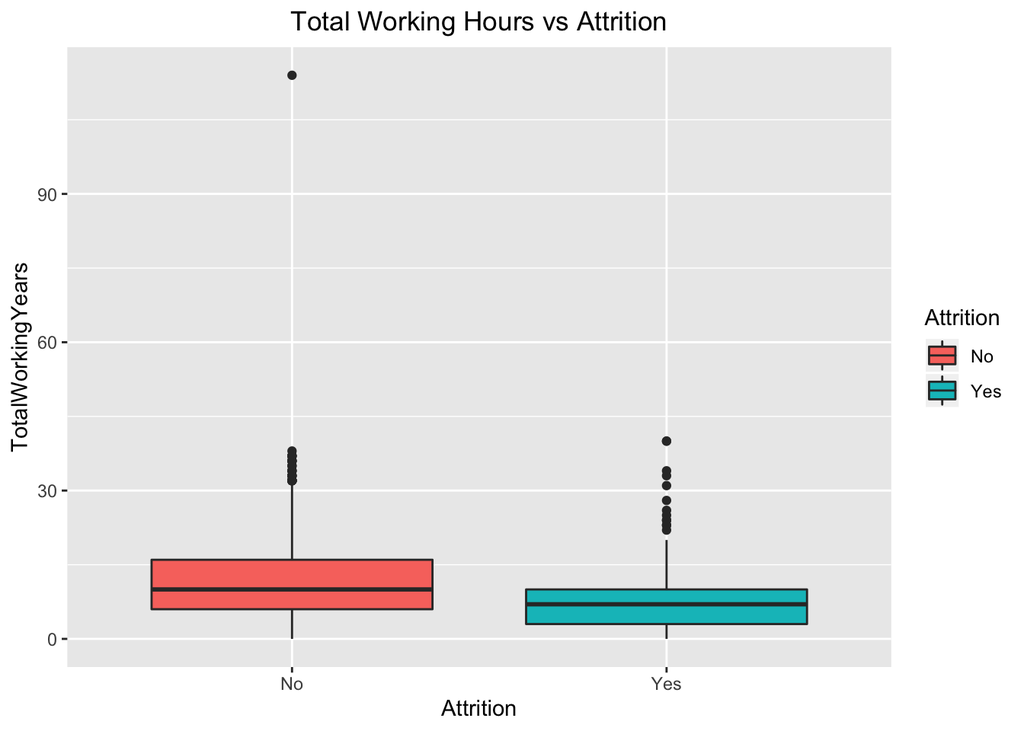

```r
ggplot(df,aes(x=Attrition,y=TotalWorkingYears,fill=Attrition))+geom_boxplot()+ggtitle('Total Working Hours vs Attrition')+theme(plot.title = element_text(hjust = 0.5))
```

#### *Training Times LastYear*

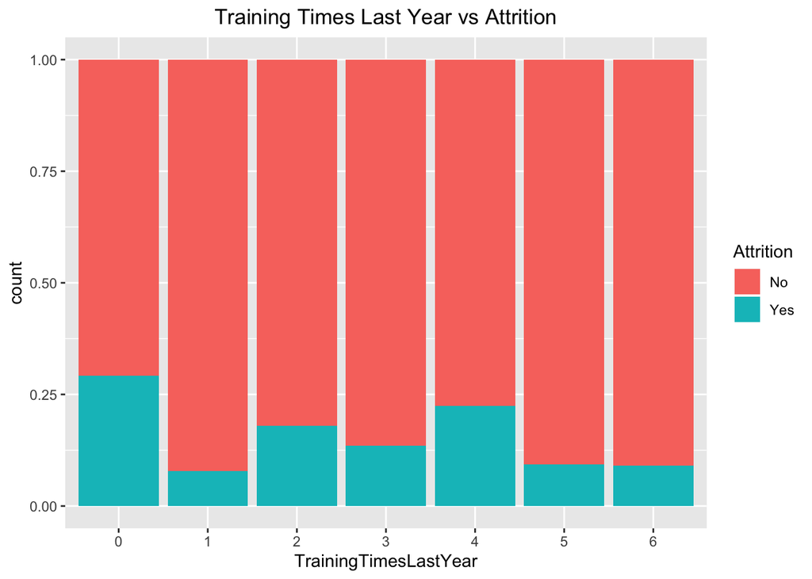

```r
ggplot(df,aes(x=TrainingTimesLastYear,fill=Attrition))+geom_bar(position = position_fill())+ggtitle('Training Times Last Year vs Attrition')+theme(plot.title = element_text(hjust = 0.5))
```

*No. of trainings has variable effect on Attrition rate*

#### *WorkLife Balance*

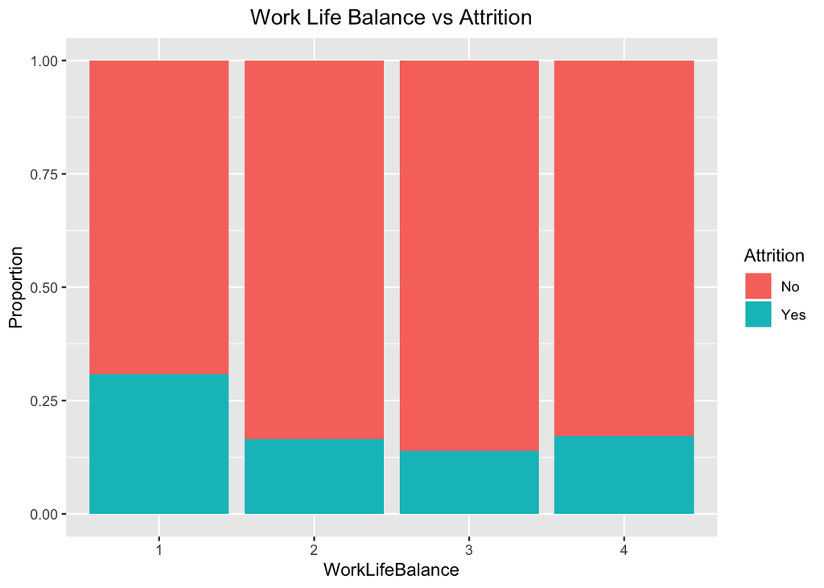

```r
ggplot(df, aes(x=WorkLifeBalance,fill=Attrition)) + geom_bar(position = position_fill()) +
  labs(y="Proportion")+ggtitle('Work Life Balance vs Attrition')+theme(plot.title = element_text(hjust = 0.5))
```

*Employees who have a difficult time in managing worklife tends to leave the company*

#### *Years At Company*

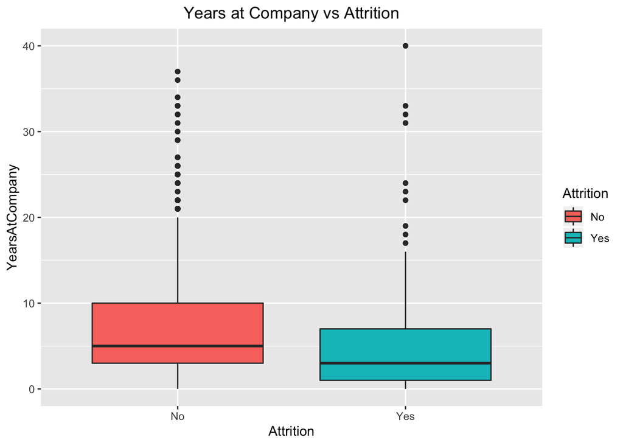

```r
ggplot(df,aes(x=Attrition,y=YearsAtCompany,fill=Attrition))+geom_boxplot()+ggtitle('Years at Company vs Attrition')+theme(plot.title = element_text(hjust = 0.5))
```

*Employees who are working in the company for a longtime stay in the company whereas other hop to other company*

#### *Years In Current Role*

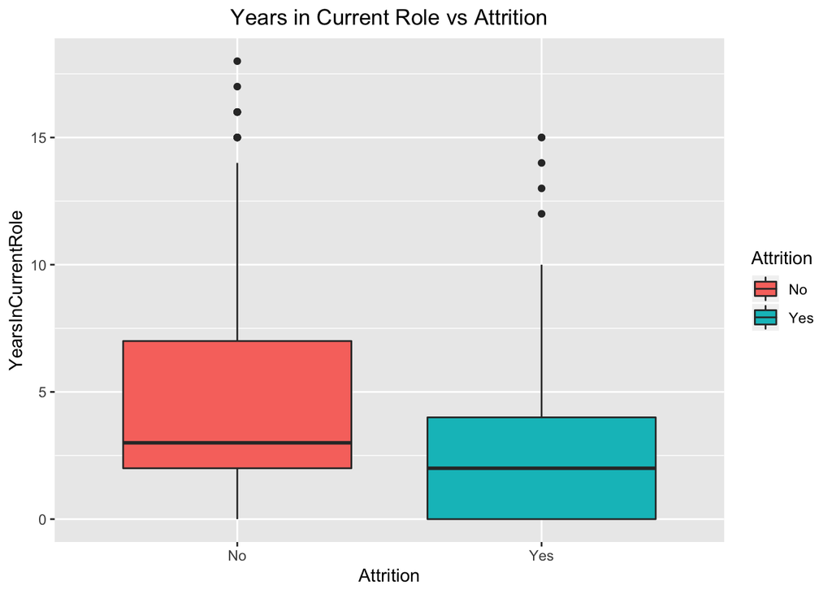

```r
ggplot(df,aes(x=Attrition,y=YearsInCurrentRole,fill=Attrition))+geom_boxplot()+ggtitle('Years in Current Role vs Attrition')+theme(plot.title = element_text(hjust = 0.5))
```

*Employees whose role of work is changed frequently have a chance of leaving the company*

## DISCRETIZATION

#### *Loading dataframe into a new variable*

```r
data<-df
```

#### *Function to discretize the attributes*

```r
breaks<-function(variable)
{
  discretize(variable, method = "frequency",breaks = 3, labels = c("low","medium", "high"))
}
```

#### *Discretizing the attributes*

```r
for (i in c(1,4,6,11,17,18,19,21,25,28,29))
{
  data[,i]<-breaks(data[,i])
}
```

#### *Function to discretize data with few datapoints*

```r
breaks2<-function(input)
{
  v<-input
  b<-quantile(input,c(0.25,0.75))
  v[input<=b[1]]<-"low"
  v[input>b[1] & input<b[2]]<-"medium"
  v[input>=b[2]]<-"high"
  v<-factor(v)
  return(v)
}
```

#### *Discretizing the attributes*

```r
data$YearsSinceLastPromotion<-breaks2(data$YearsSinceLastPromotion)
data$YearsWithCurrManager<-breaks2(data$YearsWithCurrManager)
```

#### *Checking the structure of data*

```r
str(data)
```

```
## 'data.frame':    1176 obs. of  31 variables:
##  $ Age                     : Factor w/ 3 levels "low","medium",..: 1 3 3 3 2 3 3 1 2 1 ...
##   ..- attr(*, "discretized:breaks")= num  18 32 40 60
##   ..- attr(*, "discretized:method")= chr "frequency"
##  $ Attrition               : Factor w/ 2 levels "No","Yes": 1 1 1 1 1 1 1 1 1 2 ...
##  $ BusinessTravel          : Factor w/ 3 levels "Non-Travel","Travel_Frequently",..: 3 3 3 1 3 3 3 3 3 3 ...
##  $ DailyRate               : Factor w/ 3 levels "low","medium",..: 3 3 1 1 2 3 2 1 3 3 ...
##   ..- attr(*, "discretized:breaks")= num  102 574 1039 1499
##   ..- attr(*, "discretized:method")= chr "frequency"
##  $ Department              : Factor w/ 3 levels "Human Resources",..: 3 2 3 2 2 3 2 2 2 3 ...
##  $ DistanceFromHome        : Factor w/ 3 levels "low","medium",..: 3 3 3 2 3 3 1 3 2 1 ...
##   ..- attr(*, "discretized:breaks")= num  1 4 10 224
##   ..- attr(*, "discretized:method")= chr "frequency"
##  $ Education               : Factor w/ 5 levels "1","2","3","4",..: 1 4 2 1 3 4 2 1 2 1 ...
##  $ EducationField          : Factor w/ 6 levels "Human Resources",..: 2 2 4 4 2 3 2 2 5 3 ...
##  $ EnvironmentSatisfaction : Factor w/ 4 levels "1","2","3","4": 4 4 3 4 4 1 4 1 4 3 ...
##  $ Gender                  : Factor w/ 2 levels "Female","Male": 2 1 1 2 1 1 1 2 1 2 ...
##  $ HourlyRate              : Factor w/ 3 levels "low","medium",..: 3 3 2 1 3 2 1 3 1 3 ...
##   ..- attr(*, "discretized:breaks")= num  30 54 78 100
##   ..- attr(*, "discretized:method")= chr "frequency"
##  $ JobInvolvement          : Factor w/ 4 levels "1","2","3","4": 3 3 2 2 2 3 2 3 2 3 ...
##  $ JobLevel                : Factor w/ 5 levels "1","2","3","4",..: 2 2 2 4 3 4 2 2 1 1 ...
##  $ JobRole                 : Factor w/ 9 levels "Healthcare Representative",..: 8 3 8 1 1 4 5 3 3 9 ...
##  $ JobSatisfaction         : Factor w/ 4 levels "1","2","3","4": 3 3 3 2 2 3 4 3 3 1 ...
##  $ MaritalStatus           : Factor w/ 3 levels "Divorced","Married",..: 2 2 3 1 3 2 2 3 2 1 ...
##  $ MonthlyIncome           : Factor w/ 3 levels "low","medium",..: 2 1 2 3 3 3 2 1 2 1 ...
##   ..- attr(*, "discretized:breaks")= num  1009 3695 6546 19973
##   ..- attr(*, "discretized:method")= chr "frequency"
##  $ MonthlyRate             : Factor w/ 3 levels "low","medium",..: 1 3 1 3 3 1 1 3 2 2 ...
##   ..- attr(*, "discretized:breaks")= num  2094 10228 18771 26999
##   ..- attr(*, "discretized:method")= chr "frequency"
##  $ NumCompaniesWorked      : Factor w/ 3 levels "low","medium",..: 3 3 3 2 2 2 3 1 2 1 ...
##   ..- attr(*, "discretized:breaks")= num  0 1 3 9
##   ..- attr(*, "discretized:method")= chr "frequency"
##  $ OverTime                : Factor w/ 2 levels "No","Yes": 1 1 1 2 1 1 2 1 1 1 ...
##  $ PercentSalaryHike       : Factor w/ 3 levels "low","medium",..: 2 3 3 2 3 2 2 2 1 1 ...
##   ..- attr(*, "discretized:breaks")= num  11 13 17 25
##   ..- attr(*, "discretized:method")= chr "frequency"
##  $ PerformanceRating       : Factor w/ 2 levels "3","4": 1 2 1 1 1 1 1 1 1 1 ...
##  $ RelationshipSatisfaction: Factor w/ 4 levels "1","2","3","4": 3 2 1 4 4 3 4 2 2 2 ...
##  $ StockOptionLevel        : Factor w/ 4 levels "0","1","2","3": 3 2 1 2 1 2 2 1 2 2 ...
##  $ TotalWorkingYears       : Factor w/ 3 levels "low","medium",..: 1 2 2 3 2 3 2 1 1 1 ...
##   ..- attr(*, "discretized:breaks")= num  0 7 12 114
##   ..- attr(*, "discretized:method")= chr "frequency"
##  $ TrainingTimesLastYear   : Factor w/ 7 levels "0","1","2","3",..: 3 4 7 4 4 3 5 3 4 4 ...
##  $ WorkLifeBalance         : Factor w/ 4 levels "1","2","3","4": 2 3 3 3 1 2 3 3 3 3 ...
##  $ YearsAtCompany          : Factor w/ 3 levels "low","medium",..: 1 2 2 3 3 3 2 2 2 2 ...
##   ..- attr(*, "discretized:breaks")= num  0 4 8 40
##   ..- attr(*, "discretized:method")= chr "frequency"
##  $ YearsInCurrentRole      : Factor w/ 3 levels "low","medium",..: 1 2 2 3 3 3 2 2 2 2 ...
##   ..- attr(*, "discretized:breaks")= num  0 2 6 18
##   ..- attr(*, "discretized:method")= chr "frequency"
##  $ YearsSinceLastPromotion : Factor w/ 3 levels "high","low","medium": 1 3 2 1 1 1 2 3 2 2 ...
##  $ YearsWithCurrManager    : Factor w/ 3 levels "high","low","medium": 2 3 3 2 3 1 2 2 3 2 ...
```

## ASSOCIATION RULES USING APRIORI ALGORITHM

#### *Converting the dataframe into a transactions matrix*

```r
ar<-as(data,'transactions')
```

#### *Running the data through the algorithm to find rules when Attrition is Yes*

```r
rules<-apriori(ar,parameter = list(support=0.02,confidence=0.7,minlen=3,maxlen=15),appearance = list(default="lhs",rhs="Attrition=Yes"))
```

```
## Apriori
##
## Parameter specification:
##  confidence minval smax arem  aval originalSupport maxtime support minlen
##         0.7    0.1    1 none FALSE            TRUE       5    0.02      3
##  maxlen target   ext
##      15  rules FALSE
##
## Algorithmic control:
##  filter tree heap memopt load sort verbose
##     0.1 TRUE TRUE  FALSE TRUE    2    TRUE
##
## Absolute minimum support count: 23
##
## set item appearances ...[1 item(s)] done [0.00s].
## set transactions ...[112 item(s), 1176 transaction(s)] done [0.00s].
## sorting and recoding items ... [112 item(s)] done [0.00s].
## creating transaction tree ... done [0.00s].
## checking subsets of size 1 2 3 4 5 6 7 8 9 10 11 12 done [3.45s].
## writing ... [347 rule(s)] done [0.09s].
## creating S4 object  ... done [0.22s].
```

#### *Sorting the rules based on lift and displaying top 5 rules*

```r
toprules <- sort(rules, decreasing = TRUE, na.last = NA, by = "lift")
inspect(head(toprules,5))
```

```
##     lhs                                   rhs                support confidence     lift count
## [1] {JobLevel=1,
##      OverTime=Yes,
##      StockOptionLevel=0,
##      YearsSinceLastPromotion=low}      => {Attrition=Yes} 0.02040816  0.8571429 5.448649    24
## [2] {JobLevel=1,
##      MonthlyIncome=low,
##      OverTime=Yes,
##      StockOptionLevel=0,
##      YearsSinceLastPromotion=low}      => {Attrition=Yes} 0.02040816  0.8571429 5.448649    24
## [3] {MonthlyIncome=low,
##      OverTime=Yes,
##      StockOptionLevel=0,
##      YearsSinceLastPromotion=low}      => {Attrition=Yes} 0.02040816  0.8275862 5.260764    24
## [4] {DistanceFromHome=high,
##      MonthlyIncome=low,
##      OverTime=Yes,
##      YearsWithCurrManager=low}         => {Attrition=Yes} 0.02040816  0.8000000 5.085405    24
## [5] {Age=low,
##      BusinessTravel=Travel_Frequently,
##      MonthlyIncome=low,
##      TotalWorkingYears=low,
##      YearsWithCurrManager=low}         => {Attrition=Yes} 0.02040816  0.8000000 5.085405    24
```

#### *Running the data through the algorithm to find rules when Attrition is No*

```r
rules1<-apriori(ar,parameter = list(support=0.1,confidence=0.5,minlen=3),appearance = list(default="lhs",rhs="Attrition=No"))
```

```
## Apriori
##
## Parameter specification:
##  confidence minval smax arem  aval originalSupport maxtime support minlen
##         0.5    0.1    1 none FALSE            TRUE       5     0.1      3
##  maxlen target   ext
##      10  rules FALSE
##
## Algorithmic control:
##  filter tree heap memopt load sort verbose
##     0.1 TRUE TRUE  FALSE TRUE    2    TRUE
##
## Absolute minimum support count: 117
##
## set item appearances ...[1 item(s)] done [0.00s].
## set transactions ...[112 item(s), 1176 transaction(s)] done [0.00s].
## sorting and recoding items ... [90 item(s)] done [0.00s].
## creating transaction tree ... done [0.00s].
## checking subsets of size 1 2 3 4 5 6 7 done [0.03s].
## writing ... [4630 rule(s)] done [0.00s].
## creating S4 object  ... done [0.00s].
```

#### *Sorting the rules based on lift and displaying top 5 rules*

```r
toprules1 <- sort(rules1, decreasing = TRUE, na.last = NA, by = "lift")
inspect(head(toprules1,5))
```

```
##     lhs                                    rhs              support confidence     lift count
## [1] {Department=Research & Development,
##      JobLevel=2,
##      PerformanceRating=3,
##      WorkLifeBalance=3}                 => {Attrition=No} 0.1003401  0.9752066 1.157258   118
## [2] {Department=Research & Development,
##      OverTime=No,
##      StockOptionLevel=1,
##      WorkLifeBalance=3}                 => {Attrition=No} 0.1105442  0.9701493 1.151257   130
## [3] {JobInvolvement=3,
##      OverTime=No,
##      StockOptionLevel=1,
##      WorkLifeBalance=3}                 => {Attrition=No} 0.1011905  0.9674797 1.148089   119
## [4] {JobInvolvement=3,
##      OverTime=No,
##      PerformanceRating=3,
##      YearsWithCurrManager=high}         => {Attrition=No} 0.1130952  0.9637681 1.143684   133
## [5] {OverTime=No,
##      StockOptionLevel=1,
##      WorkLifeBalance=3}                 => {Attrition=No} 0.1709184  0.9617225 1.141257   201
```

*We can get the best rules by fine tuning the Hyper-parameters. There is no overfitting or underfitting because arules is unsupervised learning algorithm.*  
*The rules displayed above are the most significant and interesting rules because of their higher lift values.*  
*If the lift value is higher than 1, it lets us know the degree to which those two occurrences are dependent on one another, and makes those rules potentially useful for predicting the related target variable in the future datasets.*